# Practica 1 Rezago Social

## Modelo con menor error: Crear subíndice con variables de cargas altas

```r
variables_altas <- c("PobAnalfabeta15m", "ViviendasPisoTierra",
                     "Viviendassinlavadora", "Viviendassinrefrigerador")

modelo_reducido <- '
  RezagoSocial =~ PobAnalfabeta15m + ViviendasPisoTierra +
                  Viviendassinlavadora + Viviendassinrefrigerador
'
```

Revisamos el ajste del modelo reducido

```r
ajuste_reducido <- cfa(modelo_reducido, data = D, estimator = "MLR")

fitmeasures(ajuste_reducido, c("chisq.scaled", "df", "pvalue.scaled",
                               "cfi.robust", "tli.robust",
                               "rmsea.robust", "srmr"))
```

```
##  chisq.scaled            df pvalue.scaled    cfi.robust    tli.robust
##        31.416         2.000         0.000         0.993         0.979
##  rmsea.robust          srmr
##         0.107         0.019
```

```r
# Extraer scores del modelo reducido
scores_reducido <- lavPredict(ajuste_reducido, method = "regression")
D$ScoreReducido <- scores_reducido[,1]
```

Correlación entre las distintas posibilidades

```r
cor1 <- cor(D$ScoreCFA, indice_original)
cor2 <- cor(D$ScoreReducido, indice_original)
cor3 <- cor(D$ScoreCFA, D$ScoreReducido)

cat("\n=== RESUMEN DE CORRELACIONES ===\n")
```

```
##
## === RESUMEN DE CORRELACIONES ===
```

```r
cat("Modelo completo vs Índice original:", round(cor1, 4), "\n")
```

```
## Modelo completo vs Índice original: 0.9684
```

```r
cat("Modelo reducido vs Índice original:", round(cor2, 4), "\n")
```

```
## Modelo reducido vs Índice original: 0.9182
```

```r
cat("Modelo completo vs Modelo reducido:", round(cor3, 4), "\n")
```

```
## Modelo completo vs Modelo reducido: 0.9866
```

Gráfico 2: Reducido vs Original

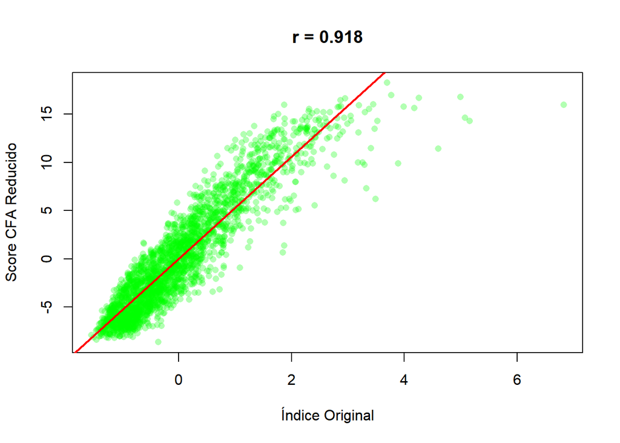

```r
plot(indice_original, D$ScoreReducido,
     xlab = "Índice Original", ylab = "Score CFA Reducido",
     main = paste("r =", round(cor2, 3)), pch = 16, col = rgb(0,1,0,0.3))
abline(lm(D$ScoreReducido ~ indice_original), col = "red", lwd = 2)
```

Comparamos la convergencia de los grupos (quintiles)

```r
D$quintil_original <- cut(indice_original,
                          breaks = quantile(indice_original, probs = seq(0, 1, 0.2), na.rm = TRUE),
                          labels = c("Q1-Muy Bajo", "Q2-Bajo", "Q3-Medio", "Q4-Alto", "Q5-Muy Alto"),
                          include.lowest = TRUE)

D$quintil_reducido <- cut(D$ScoreReducido,
                          breaks = quantile(D$ScoreReducido, probs = seq(0, 1, 0.2), na.rm = TRUE),
                          labels = c("Q1-Muy Bajo", "Q2-Bajo", "Q3-Medio", "Q4-Alto", "Q5-Muy Alto"),
                          include.lowest = TRUE)

# 2. Tabla de contingencia
tabla_cruzada <- table(D$quintil_original, D$quintil_reducido)
print(tabla_cruzada)
```

```
##
##               Q1-Muy Bajo Q2-Bajo Q3-Medio Q4-Alto Q5-Muy Alto
##   Q1-Muy Bajo         345     132       17       0           0
##   Q2-Bajo             138     209      137      10           0
##   Q3-Medio             11     136      216     129           1
##   Q4-Alto               0      17      119     288          70
##   Q5-Muy Alto           0       0        4      67         423
```

Calculamos la proporción de acuerdo

```r
library(psych)
cohen.kappa(tabla_cruzada)
```

```
## Call: cohen.kappa1(x = x, w = w, n.obs = n.obs, alpha = alpha, levels = levels,
##     w.exp = w.exp)
##
## Cohen Kappa and Weighted Kappa correlation coefficients and confidence boundaries
##                  lower estimate upper
## unweighted kappa  0.48     0.50  0.52
## weighted kappa    0.87     0.88  0.89
##
##  Number of subjects = 2469
```

```r
acuerdo_exacto <- sum(diag(tabla_cruzada)) / sum(tabla_cruzada) * 100
cat("\nPorcentaje de acuerdo exacto:", round(acuerdo_exacto, 2), "%\n")
```

```
##
## Porcentaje de acuerdo exacto: 59.98 %
```

Ahora para el modelo unidimensional completo

```r
# 1. Crear quintiles para índice original y modelo completo
D$quintil_original <- cut(indice_original,
                          breaks = quantile(indice_original, probs = seq(0, 1, 0.2), na.rm = TRUE),
                          labels = c("Q1-Muy Bajo", "Q2-Bajo", "Q3-Medio", "Q4-Alto", "Q5-Muy Alto"),
                          include.lowest = TRUE)

D$quintil_completo <- cut(D$ScoreCFA,
                          breaks = quantile(D$ScoreCFA, probs = seq(0, 1, 0.2), na.rm = TRUE),
                          labels = c("Q1-Muy Bajo", "Q2-Bajo", "Q3-Medio", "Q4-Alto", "Q5-Muy Alto"),
                          include.lowest = TRUE)

# 2. Tabla de contingencia
tabla_cruzada_completo <- table(D$quintil_original, D$quintil_completo)
print(tabla_cruzada_completo)
```

```
##
##               Q1-Muy Bajo Q2-Bajo Q3-Medio Q4-Alto Q5-Muy Alto
##   Q1-Muy Bajo         403      91        0       0           0
##   Q2-Bajo              90     312       92       0           0
##   Q3-Medio              1      91      311      90           0
##   Q4-Alto               0       0       90     354          50
##   Q5-Muy Alto           0       0        0      50         444
```

```r
# 3. Tabla de contingencia con proporciones
cat("\n=== PROPORCIONES POR FILA (%) ===\n")
```

```
##
## === PROPORCIONES POR FILA (%) ===
```

```r
print(round(prop.table(tabla_cruzada_completo, margin = 1) * 100, 1))
```

```
##
##               Q1-Muy Bajo Q2-Bajo Q3-Medio Q4-Alto Q5-Muy Alto
##   Q1-Muy Bajo        81.6    18.4      0.0     0.0         0.0
##   Q2-Bajo            18.2    63.2     18.6     0.0         0.0
##   Q3-Medio            0.2    18.5     63.1    18.3         0.0
##   Q4-Alto             0.0     0.0     18.2    71.7        10.1
##   Q5-Muy Alto         0.0     0.0      0.0    10.1        89.9
```

```r
kappa_completo <- cohen.kappa(tabla_cruzada_completo)
print(kappa_completo)
```

```
## Call: cohen.kappa1(x = x, w = w, n.obs = n.obs, alpha = alpha, levels = levels,
##     w.exp = w.exp)
##
## Cohen Kappa and Weighted Kappa correlation coefficients and confidence boundaries
##                  lower estimate upper
## unweighted kappa  0.65     0.67  0.70
## weighted kappa    0.93     0.93  0.94
##
##  Number of subjects = 2469
```

```r
# Porcentaje de acuerdo exacto
acuerdo_exacto_completo <- sum(diag(tabla_cruzada_completo)) / sum(tabla_cruzada_completo) * 100
cat("\nPorcentaje de acuerdo exacto (Modelo Completo):", round(acuerdo_exacto_completo, 2), "%\n")
```

```
##
## Porcentaje de acuerdo exacto (Modelo Completo): 73.88 %
```

# Sobre la comparailidad del IRS

CONEVAL:

Para el cálculo del Índice de Rezago Social se utiliza el método de Análisis de Componentes Principales (ACP), este reduce el número de dimensiones de un conjunto de variables asociadas a la variable de estudio, cuyas nuevas dimensiones se crean estableciendo una combinación lineal de las variables originales (Jolliffe, 2002; Vidal; Ma & Sastry, 2016); sin embargo, el método de ACP, por sí sólo no permite realizar un análisis del Índice de Rezago Social en el tiempo.

La estimación del IRS se realiza de manera independiente para cada nivel de desagregación geográfica mediante la aplicación de la técnica de ACP; es decir, se aplica la técnica estadística por separado para entidades, municipios y localidades. Asimismo, en el ACP se sintetiza la información de los indicadores insumo al determinar las ponderaciones o pesos de cada indicador para generar una variable resumen, equivalente a la combinación lineal de los indicadores. Esta combinación lineal no le da el mismo peso a cada indicador, sino que cada indicador tiene un peso diferente. Lo anterior implica que, para cada desagregación geográfica, los indicadores tendrán distintos pesos en el IRS.

¿Es la técnica del APC el problema?

La comparabilidad como función de los indicadores, según el CONEVAL:

[output not shown]